# Spike-in vs No Spike-in vs Literature: Significant mRNA Counts (Lollipop Charts)

# Part 2: Candidate literature ribosome-profiling hypoxia datasets

**Status: survey of candidates; three of them are now plotted** (Hettiarachchi et al. 2019, Shen et al. 2020, Jiang et al. 2017 — see the “Net result” note below the table). Inclusion depends on comparability to our own condition (MDA-MB-231, sictrl, hypoxia vs normoxia, 1/4/24hr — exact O2% and chamber duration for our own experiment were not found documented anywhere in this repo and need to be confirmed before any “same condition” claims are made in a figure). Citations use `Author et al. YYYY` format per Kate’s request, to sit alongside our own “Pre spike-in” / “Post spike-in” bars in a future combined plot.

| Citation | Journal | Cell line | O2% hypoxia (vs normoxia) | Duration(s) | Method | Reported sig. gene/mRNA counts | Comparability notes |
| --- | --- | --- | --- | --- | --- | --- | --- |
| Jiang et al. 2017 (10.1186/s12864-017-3996-8, PMID 28826393, PMC5563900) — Jiang Z, Yang J, Dai A, Wang Y, Li W, Xie Z. “Ribosome profiling reveals translational regulation of mammalian cells in respo… | BMC Genomics | ARPE-19 (human retinal pigment epithelium) | 1% (vs 21%) | 1h, 2h, 4h | **Simultaneous RNA-seq + Ribo-seq** (not RNA-seq only). edgeR. DEG/DTG cutoff: \|log2FC\| >= 1 AND mean logRPKM >= 3.3; DTE cutoff: FC > 2 AND mean RPKM > 5 | DEGs (mRNA): 92 (1h), 196 (2h), 212 (4h); DTGs (RPF): 128, 183, 293; DTE mRNAs: 419, 239, 158 — **direction (up vs down) is not split out at any timepoint, and is not recoverable from any file the pap… | Best O2%/timepoint match to ours (1% O2, 1h/4h) of any candidate. Non-cancer cell line. **Plotted, but as combined totals only and asterisked** (Parts 3b/4/6): their significance calls use fold-change… |
| Ho et al. 2016 | Cell Reports (10.1016/j.celrep.2016.01.036) | U87MG (glioblastoma), 786-O (renal clear cell carcinoma) | 1% (vs 21%) | 24h (+ 6h pretreatment/24h labeling variant) | Ribosome-footprint profiling + quantitative MS | No up/down significant-gene counts reported in the padj/FC-cutoff sense used here — genes instead binned into Class I/II/III translation-efficiency-ratio categories (<sub>25%/</sub>60%/~15%) | Duration matches our 24h timepoint well. Not a compatible summary statistic (no discrete “N up / N down” figure) — would need raw data reprocessing to get a comparable count, not just a citation. |
| Ho et al. 2020 | Nature Communications (10.1038/s41467-020-16504-1) | U87MG (glioblastoma) | 1% (0.1% used only in a *C. elegans* validation arm) | 24h primary, 72h confirmatory | Polysome profiling + TMT-pSILAC + RNA-seq (not ribo-seq) | HuR-knockdown-dependent: ~3,435 mRNAs affected at TE level vs. 1,323 at RNA level (2-fold threshold) — this is an RBP-knockdown effect, not a plain hypoxia-vs-normoxia comparison | Different assay (polysome profiling, not ribo-seq) and different comparison (HuR KD, not hypoxia vs normoxia) — weakest match of the four; flagging mainly because it’s from the same group/cell line as… |
| Andreev et al. 2015 | Genome Biology (10.1186/s13059-015-0651-z) | PC12 (rat pheochromocytoma, neural) | 0% O2 (anoxia) **+ glucose deprivation**, vs 21% O2 | 20min, 40min, 1h, 2h, 4h | Ribo-seq, Z-score + 10% FDR | At 40 min: 3,202 DE genes by ribo-seq occupancy; 2,556 DE genes by TE — **up/down not separated in the summary**; other timepoints not fully extracted here | Oxygen-glucose deprivation (OGD), not pure hypoxia — the hypoxia effect is not separable from glucose withdrawal. Anoxia (0% O2) is far more severe than typical 1% hypoxia protocols. Different species… |

**Not pursued further / lower priority:** - Erhard et al. 2025 (Nat Commun, HIF1α nucleolar ribosome biogenesis, breast cancer, 1% vs 20% O2) — breast-cancer relevant and O2% plausibly comparable, but the paper’s focus is rRNA transcription/ribosome biogenesis, not a ribo-seq TE up/down gene-count comparison; would need a closer read of methods/supplement to see if a comparable count exists. - van den Beucken et al. (RNA-binding-protein/anaerobic-metabolism hypoxia translation work) — repeatedly surfaced in searches but could not confirm a ribo-seq-based up/down significant-gene count in the time spent; flagging the author/topic in case Kate recognizes the specific paper she has in mind.

**Resolved:** our own hypoxia condition is 1% O2, chamber duration = the sample timepoint itself (1/4/24hr). Confirmed by Kate; not documented anywhere in this repo prior to this notebook. Under this condition, Jiang et al. 2017 (1% O2, 1h/2h/4h) is the closest O2%/duration match among the candidates above.

**Resolved (2026-08-03), Jiang et al. 2017 — checked against the paper.** This row previously carried author-year only, with no DOI, and had been questioned as possibly being an RNA-seq-only study. Both points are settled against the published article: it *is* simultaneous RNA-seq + ribosome profiling (see the title), first author Zhiwen Jiang, and the DTE counts recorded above (419/239/158) match the paper exactly.

**Revised (2026-08-18), Jiang et al. 2017 — now included, as asterisked combined totals.** The earlier resolution said Jiang et al. could not contribute a bar to any plot. That has been reversed on Kate’s decision: the dataset is the closest O2%/duration match we have (1% O2, 1h and 4h, human, simultaneous RNA-seq + Ribo-seq, all three of our modalities), and it is plotted in Parts 4 and 6 with an asterisk rather than dropped. What has *not* changed is the underlying limitation, which the asterisk carries:

- Their significance criterion contains no FDR/adjusted p-value at all (edgeR fold change plus a mean-RPKM abundance floor), so their lists cannot be re-filtered under our padj < 0.05 the way Hettiarachchi et al.’s were. The bars are their own totals under their own cutoffs.
- **Up vs down cannot be recovered from anything the paper supplies** — verified file by file in Part 3b, not assumed. So each Jiang et al. bar is a single combined total, not a dodged Up/Down pair.

The only route to directional, cutoff-matched Jiang et al. counts remains reprocessing SRA SRP094893 from raw reads through our own DESeq2, which is still out of scope. Do not re-open the supplementary files looking for direction; they have been checked.

**Net result: three published datasets are plotted — Hettiarachchi et al. 2019 (TE), Shen et al. 2020 (RNA, Ribo) and Jiang et al. 2017 (TE, RNA, Ribo; combined totals only, asterisked).** The first two are re-filtered or taken-as-reported Up/Down pairs; Jiang et al. contributes single combined-total bars for the reasons above. None of the three used spike-in normalization, so every literature bar in Parts 4-6 is effectively a no-spike-in measurement and can only speak to whether our no-spike-in numbers are plausible — it cannot adjudicate our with-spike-in counts. None is a cancer cell line (human primary hepatocytes; rat H9C2 cardiomyoblasts; human retinal pigment epithelium), so there is still no cancer-line comparator in this figure.

# Part 3: Hettiarachchi et al. 2019 comparison (human primary hepatocytes)

Hettiarachchi GK, et al. “Translational and transcriptional responses in human primary hepatocytes under hypoxia.” *Am J Physiol Gastrointest Liver Physiol* 2019. DOI: 10.1152/ajpgi.00331.2018 (PMC6620582).

- **Cell type:** pooled human primary hepatocytes from 5 donors (Thermo Fisher Scientific), mixed age/sex/phenotype.
- **O2%:** 1% hypoxia vs. ambient (~21%) normoxia — **matches our own condition exactly.**
- **Timepoints:** 30 min and 240 min of hypoxia exposure (chamber: Plas-Labs glove box, 37°C). **240 min = 4hr matches our 4hr timepoint exactly.** 30 min does not correspond exactly to any of our timepoints (our earliest is 1hr = 60min) — noted, not silently aligned.
- **Method:** RNA-seq + Ribo-seq + TE (ratio of ribosome-protected fragments to mRNA fragments), matching our own assay type.
- **Their own significance cutoffs:** |log2FC| > 1 and padj (BH-FDR) < 0.10 — looser padj, stricter LFC than ours (padj < 0.05, |log2FC| >= 0.5).
- **Their reported totals (Fig. in paper, not split by up/down):** 760 differential-TE genes at 30 min; 841 at 240 min.
- Supplied by Kate: `accessories/hettiarachchi riboseq/supplemental file s1.xls`, with per-comparison tabs including `"0 vs 30 min TE"` and `"0 vs 240 min TE"`.

```r
library(readxl)
hetti_file <- here("accessories", "hettiarachchi riboseq", "supplemental file s1.xls")
stopifnot("Hettiarachchi supplemental file not found" = file.exists(hetti_file))

hetti_sheets <- c("30min" = "0 vs 30 min TE", "240min" = "0 vs 240 min TE")

hetti_te <- lapply(hetti_sheets, function(sheet) {
  read_excel(hetti_file, sheet = sheet) %>%
    dplyr::rename(symbol = 1)
})
for (tp in names(hetti_te)) {
  cat(tp, "TE sheet rows:", nrow(hetti_te[[tp]]), "\n")
}
```

```
## 30min TE sheet rows: 760
## 240min TE sheet rows: 841
```

## Important caveat: the supplied TE tabs are already pre-filtered to the authors’ own significant gene set

```r
for (tp in names(hetti_te)) {
  d <- hetti_te[[tp]]
  stopifnot(
    "Expected every row to already pass the paper's own |log2FC| > 1 cutoff" =
      all(abs(d$log2FoldChange) > 1, na.rm = TRUE),
    "Expected every row to already pass the paper's own padj < 0.10 cutoff" =
      all(d$padj < 0.10, na.rm = TRUE)
  )
}
cat("Confirmed: both TE tabs contain only the", nrow(hetti_te[["30min"]]),
    "/", nrow(hetti_te[["240min"]]), "genes the authors themselves called\n")
```

```
## Confirmed: both TE tabs contain only the 760 / 841 genes the authors themselves called
```

```r
cat("significant (|log2FC| > 1, padj < 0.10) — NOT the full genome-wide DESeq2 output.\n")
```

```
## significant (|log2FC| > 1, padj < 0.10) — NOT the full genome-wide DESeq2 output.
```

Row counts (760, 841) match the paper’s reported totals exactly, confirming these tabs are the authors’ final significant-gene lists, not unfiltered results. **Consequence:** applying our own thresholds below only re-filters *within* this already-significant set. Any gene with 0.5 <= |log2FC| < 1 that would have passed our padj < 0.05 cutoff on the full dataset is absent from this file entirely — so the counts below are a **lower bound**, not the true count we’d get from the full unfiltered Hettiarachchi et al. DESeq2 results (which were not supplied).

## Reproducibility check: applying their exact cutoffs to their own data reproduces their reported totals

```r
paper_reported_total <- c("30min" = 760, "240min" = 841)

for (tp in names(hetti_te)) {
  d <- hetti_te[[tp]]
  n_matching_their_cutoffs <- sum(abs(d$log2FoldChange) > 1 & d$padj < 0.10, na.rm = TRUE)
  cat(tp, ": applying |log2FC| > 1 & padj < 0.10 to their data gives",
      n_matching_their_cutoffs, "genes (they reported", paper_reported_total[[tp]], ")\n")
  stopifnot(
    "Reapplying the paper's own cutoffs to their own data did not reproduce their reported total" =
      n_matching_their_cutoffs == paper_reported_total[[tp]]
  )
}
```

```
## 30min : applying |log2FC| > 1 & padj < 0.10 to their data gives 760 genes (they reported 760 )
## 240min : applying |log2FC| > 1 & padj < 0.10 to their data gives 841 genes (they reported 841 )
```

```r
cat("Confirmed: their cutoffs reproduce their reported totals exactly at both timepoints.\n")
```

```
## Confirmed: their cutoffs reproduce their reported totals exactly at both timepoints.
```

## Apply our thresholds (padj < 0.05, |log2FC| >= 0.5) and compare to their reported totals

```r
count_sig_hetti <- function(d) {
  sig <- d %>% filter(!is.na(padj), padj < 0.05, abs(log2FoldChange) >= 0.5)
  tibble(Up = sum(sig$log2FoldChange > 0), Down = sum(sig$log2FoldChange < 0))
}

hetti_counts <- map_dfr(names(hetti_te), function(tp) {
  count_sig_hetti(hetti_te[[tp]]) %>% mutate(Timepoint = tp)
}) %>%
  mutate(Our_threshold_total = Up + Down)

hetti_comparison <- hetti_counts %>%
  mutate(
    Paper_reported_total = c(`30min` = 760, `240min` = 841)[Timepoint],
    Paper_cutoffs = "|log2FC| > 1, padj < 0.10 (not split by direction)"
  ) %>%
  dplyr::select(Timepoint, Up, Down, Our_threshold_total, Paper_reported_total, Paper_cutoffs)

print(hetti_comparison)
```

```
## # A tibble: 2 × 6
##   Timepoint    Up  Down Our_threshold_total Paper_reported_total Paper_cutoffs
##   <chr>     <int> <int>               <int>                <dbl> <chr>
## 1 30min       359   262                 621                  760 |log2FC| > 1, …
## 2 240min      278   345                 623                  841 |log2FC| > 1, …
```

```r
write_csv(hetti_comparison, here("output/spikein_literature_comparison/02_hettiarachchi_te_comparison.csv"))
cat("Saved Hettiarachchi et al. 2019 TE comparison to output/spikein_literature_comparison/\n")
```

```
## Saved Hettiarachchi et al. 2019 TE comparison to output/spikein_literature_comparison/
```

Our-threshold total will be <= the paper’s reported total at each timepoint (subset of an already-filtered set, per the caveat above) — this is expected and not evidence of a discrepancy in either analysis.

# Part 3b: Jiang et al. 2017 comparison (ARPE-19, 1% O2, 1/2/4hr)

Jiang Z, Yang J, Dai A, Wang Y, Li W, Xie Z. “Ribosome profiling reveals translational regulation of mammalian cells in response to hypoxic stress.” *BMC Genomics* 2017. DOI: 10.1186/s12864-017-3996-8 (PMID 28826393, PMC5563900). Raw data: SRA SRP094893.

- **Cell type:** ARPE-19 (human retinal pigment epithelium) — human, but not a cancer line.
- **O2%:** 1% vs 21% — **matches our own condition exactly.**
- **Timepoints:** 1h, 2h and 4h of hypoxia vs 0h. **1h and 4h match two of our three timepoints exactly** — the best O2%/duration match of anything surveyed in Part 2. Only 1h and 4h are plotted; 2h has no counterpart of ours, and our 24hr has no counterpart of theirs.
- **Method:** simultaneous RNA-seq + Ribo-seq, edgeR. Reports all three of the modalities we do: DEGs (RNA), DTGs (RPF/Ribo) and DTE mRNAs (TE) — the only literature source here that covers all three.
- **Their own cutoffs:** DEG/DTG = |log2FC| >= 1 AND mean logRPKM >= 3.3; DTE = FC > 2 AND mean RPKM > 5. **No FDR or adjusted p-value anywhere in the criterion**, so unlike Hettiarachchi et al. these lists cannot be re-filtered under our padj < 0.05, and the abundance floor cannot be undone. Their counts are used as reported.
- Source file: `accessories/jiang riboseq/12864_2017_3996_MOESM2_ESM.xlsx` (the paper’s Additional file 2), downloaded from the publisher.

## Why the Jiang et al. bars are combined totals, not Up/Down

Checked file by file (2026-08-18) rather than assumed. Additional file 2 is **gene symbols only**: nine columns (3 timepoints x RNA-seq / Ribo-seq / TE), each headed `No. = N`, with no log2FC, no p-value and no direction column anywhere. Additional files 3 and 4 are GO biological-process enrichment tables (term + adjusted p); Additional file 1 is the supplementary figures. There is also **no GEO series** for this study — SRP094893 is SRA-only (16 runs) — so no processed per-gene expression table exists from which the sign of the fold change could be taken either.

Consequence: each Jiang et al. bar in Parts 4 and 6 is **one combined (up + down) total**, drawn as a single centred bar labelled `Total` and marked with an asterisk in the axis label, rather than the dodged Up/Down pair used for every other source. Splitting it would require reprocessing SRP094893 from raw reads.

```r
jiang_file <- here("accessories", "jiang riboseq", "12864_2017_3996_MOESM2_ESM.xlsx")
stopifnot("Jiang et al. 2017 Additional file 2 not found" = file.exists(jiang_file))

# Wide layout: rows 1-4 are headers (sheet title / timepoint / modality /
# "No. = N"); gene symbols start at row 5. Columns run 1h, 2h, 4h, each as
# RNA-seq, Ribo-seq, TE.
jiang_raw <- read_excel(jiang_file, sheet = "DE_genes", col_names = FALSE)
```

```r
jiang_genes <- function(j) {
  g <- jiang_raw[[j]][5:nrow(jiang_raw)]
  g[!is.na(g)]
}

jiang_counts <- tibble(
  col       = 1:9,
  Timepoint = rep(c("1hr", "2hr", "4hr"), each = 3),
  Modality  = rep(c("RNA", "Ribo", "TE"), times = 3)
) %>%
  mutate(
    stated = as.integer(sub("No\\. = ", "", as.character(unlist(jiang_raw[4, col])))),
    n      = map_int(col, ~ length(jiang_genes(.x)))
  )

print(jiang_counts)
```

```
## # A tibble: 9 × 5
##     col Timepoint Modality stated     n
##   <int> <chr>     <chr>     <int> <int>
## 1     1 1hr       RNA          92    92
## 2     2 1hr       Ribo        128   128
## 3     3 1hr       TE          419   419
## 4     4 2hr       RNA         196   196
## 5     5 2hr       Ribo        183   183
## 6     6 2hr       TE          239   239
## 7     7 4hr       RNA         212   212
## 8     8 4hr       Ribo        293   293
## 9     9 4hr       TE          158   158
```

## Reproducibility check: the file reproduces the paper’s reported counts

Required before any external dataset enters a figure. The nine `No. = N` headers in Additional file 2 are checked against the totals recorded from the paper in Part 2’s table, and the gene lists underneath are checked against their own headers — so a mis-parsed column or a wrong sheet cannot pass silently. (The 2h RNA-seq column reads 196; Part 2’s table previously recorded 192 for it, now corrected. 2h is not plotted, and both plotted timepoints — 1h and 4h — match the paper exactly.)

```r
# Order matches jiang_counts: 1h RNA/Ribo/TE, 2h RNA/Ribo/TE, 4h RNA/Ribo/TE
jiang_paper_reported <- c(92, 128, 419, 196, 183, 239, 212, 293, 158)

stopifnot(
  "Jiang Additional file 2 column headers do not match the counts recorded from the paper" =
    all(jiang_counts$stated == jiang_paper_reported),
  "Jiang gene-list lengths do not match their own 'No. = N' column headers" =
    all(jiang_counts$n == jiang_counts$stated),
  "Jiang gene lists contain duplicates - column parsing is wrong" =
    all(map_int(jiang_counts$col, ~ sum(duplicated(jiang_genes(.x)))) == 0)
)

# Biological spot-check: VEGFA is the canonical HIF-1 target and must be among
# the RNA-seq DEGs at both plotted timepoints if the columns are what they claim.
stopifnot(
  "VEGFA missing from Jiang 1h RNA-seq DEGs - column mapping is likely wrong" =
    "VEGFA" %in% jiang_genes(1),
  "VEGFA missing from Jiang 4h RNA-seq DEGs - column mapping is likely wrong" =
    "VEGFA" %in% jiang_genes(7)
)

cat("Confirmed: all 9 Jiang et al. gene lists match their reported counts;",
    "VEGFA present in the 1h and 4h RNA-seq DEG lists.\n")
```

```
## Confirmed: all 9 Jiang et al. gene lists match their reported counts; VEGFA present in the 1h and 4h RNA-seq DEG lists.
```

```r
# Only the timepoints that match ours are plotted (1hr, 4hr); 2hr is dropped.
jiang_plot_counts <- jiang_counts %>%
  filter(Timepoint %in% c("1hr", "4hr")) %>%
  mutate(
    Direction = "Total",
    source = paste0("Jiang et al. 2017*<br>(", Timepoint, ", 1% O2,<br>ARPE-19)")
  ) %>%
  dplyr::select(Modality, Timepoint, source, Direction, n)

print(jiang_plot_counts)
```

```
## # A tibble: 6 × 5
##   Modality Timepoint source                                      Direction     n
##   <chr>    <chr>     <chr>                                       <chr>     <int>
## 1 RNA      1hr       Jiang et al. 2017*<br>(1hr, 1% O2,<br>ARPE… Total        92
## 2 Ribo     1hr       Jiang et al. 2017*<br>(1hr, 1% O2,<br>ARPE… Total       128
## 3 TE       1hr       Jiang et al. 2017*<br>(1hr, 1% O2,<br>ARPE… Total       419
## 4 RNA      4hr       Jiang et al. 2017*<br>(4hr, 1% O2,<br>ARPE… Total       212
## 5 Ribo     4hr       Jiang et al. 2017*<br>(4hr, 1% O2,<br>ARPE… Total       293
## 6 TE       4hr       Jiang et al. 2017*<br>(4hr, 1% O2,<br>ARPE… Total       158
```

# Part 4: TE comparison (1/4/24hr) — with spike-in vs no spike-in vs Hettiarachchi et al. 2019 and Jiang et al. 2017

Reorganized to match the layout used for the final combined plot in `04_bar_te_si3d_si3e_with_nospike_vs_literature.Rmd`: source labels on the x-axis, bars going up (count on the y-axis), axis text rotated 90° and wrapped, dotted/dashed vertical separators grouping the categories instead of interleaving them.

Left to right: **with spike-in**, all three timepoints (1hr, 4hr, 24hr) — one set of Up/Down bars per timepoint — then a **dotted** vertical line, then **no spike-in**, all three timepoints — another set of Up/Down bars per timepoint (6 “ours” sets total), then a **dashed** vertical line, then Hettiarachchi et al. 2019’s own Up/Down counts, in order of the hypoxia timepoint used (30min, then 240min), and finally Jiang et al. 2017’s DTE mRNA counts (1hr, then 4hr) as **single combined-total bars** — see Part 3b for why those cannot be split Up/Down. Unlike the previous version of this plot, our three timepoints are no longer individually paired against a matched Hettiarachchi timepoint — all “ours” bars are grouped together, all literature bars are grouped together, same as notebook 04.

All “ours” counts use **our** thresholds (padj < 0.05, |log2FC| >= 0.5), not the original publication’s cutoffs — the Hettiarachchi bars remain a lower bound (see Part 3 caveat) since their supplied data was pre-filtered under their own looser/stricter mixed cutoffs before we ever applied ours. The Hettiarachchi counts reused here (`hetti_counts`, from Part 3) were already reproducibility-checked against the paper’s own reported totals in the `hetti_reproduce_their_totals` chunk above (760 at 30min, 841 at 240min, both `stopifnot`-verified) — this section adds no new, unchecked Hettiarachchi numbers. Our 24hr timepoint has no Hettiarachchi match (the paper only reports 30min/240min) — it still gets its own with-spike/no-spike bars in the “ours” block, just no literature counterpart.

Bar fill follows notebook 04’s convention: “ours” bars (all six) share one Okabe-Ito color, literature bars are grey; Up/Down is conveyed by the bold vermillion/blue count label above each bar, not by fill. The two Jiang et al. bars carry a grey `Total` label instead and are asterisked in the axis text, so a combined total is never misread as an Up or a Down count.

```r
ours_color <- "#009E73"
literature_color <- "grey50"

our_te_all <- sig_counts_long %>%
  filter(Mode == "TE") %>%
  mutate(spike_status = factor(spike_status, levels = c("With spike-in", "No spike-in"))) %>%
  transmute(
    source = paste0("**", spike_status, " (", Timepoint, ")**"),
    Direction, n, spike_status, Timepoint
  )

hetti_30min_long <- hetti_counts %>%
  filter(Timepoint == "30min") %>%
  dplyr::select(Up, Down) %>%
  pivot_longer(everything(), names_to = "Direction", values_to = "n") %>%
  mutate(source = "Hettiarachchi et al. 2019<br>(30min, 1% O2,<br>human primary hepatocytes)")

hetti_240min_long <- hetti_counts %>%
  filter(Timepoint == "240min") %>%
  dplyr::select(Up, Down) %>%
  pivot_longer(everything(), names_to = "Direction", values_to = "n") %>%
  mutate(source = "Hettiarachchi et al. 2019<br>(240min/4hr, 1% O2,<br>human primary hepatocytes)")

# Jiang et al. 2017 DTE mRNAs (Part 3b): combined totals, no Up/Down split.
jiang_te_long <- jiang_plot_counts %>%
  filter(Modality == "TE") %>%
  dplyr::select(source, Direction, n)

source_levels <- c(
  "**With spike-in (1hr)**", "**With spike-in (4hr)**", "**With spike-in (24hr)**",
  "**No spike-in (1hr)**", "**No spike-in (4hr)**", "**No spike-in (24hr)**",
  "Hettiarachchi et al. 2019<br>(30min, 1% O2,<br>human primary hepatocytes)",
  "Hettiarachchi et al. 2019<br>(240min/4hr, 1% O2,<br>human primary hepatocytes)",
  jiang_te_long$source
)

n_ours <- 6
n_with_spike <- 3

source_colors <- setNames(
  c(rep(ours_color, n_ours), rep(literature_color, length(source_levels) - n_ours)),
  source_levels
)

te_vs_hetti <- bind_rows(
  our_te_all %>% dplyr::select(source, Direction, n),
  hetti_30min_long %>% dplyr::select(source, Direction, n),
  hetti_240min_long %>% dplyr::select(source, Direction, n),
  jiang_te_long
) %>%
  mutate(
    Direction = factor(Direction, levels = c("Up", "Down", "Total")),
    source = factor(source, levels = source_levels)
  )

stopifnot("Jiang TE bars lost between Part 3b and te_vs_hetti" =
  sum(te_vs_hetti$Direction == "Total") == 2)

print(te_vs_hetti)
```

```
## # A tibble: 18 × 3
##    source                                                        Direction     n
##    <fct>                                                         <fct>     <dbl>
##  1 **With spike-in (1hr)**                                       Up           44
##  2 **With spike-in (1hr)**                                       Down        121
##  3 **No spike-in (1hr)**                                         Up          480
##  4 **No spike-in (1hr)**                                         Down        323
##  5 **With spike-in (4hr)**                                       Up           20
##  6 **With spike-in (4hr)**                                       Down       6195
##  7 **No spike-in (4hr)**                                         Up          416
##  8 **No spike-in (4hr)**                                         Down        319
##  9 **With spike-in (24hr)**                                      Up           21
## 10 **With spike-in (24hr)**                                      Down       8825
## 11 **No spike-in (24hr)**                                        Up          561
## 12 **No spike-in (24hr)**                                        Down        733
## 13 Hettiarachchi et al. 2019<br>(30min, 1% O2,<br>human primary… Up          359
## 14 Hettiarachchi et al. 2019<br>(30min, 1% O2,<br>human primary… Down        262
## 15 Hettiarachchi et al. 2019<br>(240min/4hr, 1% O2,<br>human pr… Up          278
## 16 Hettiarachchi et al. 2019<br>(240min/4hr, 1% O2,<br>human pr… Down        345
## 17 Jiang et al. 2017*<br>(1hr, 1% O2,<br>ARPE-19)                Total       419
## 18 Jiang et al. 2017*<br>(4hr, 1% O2,<br>ARPE-19)                Total       158
```

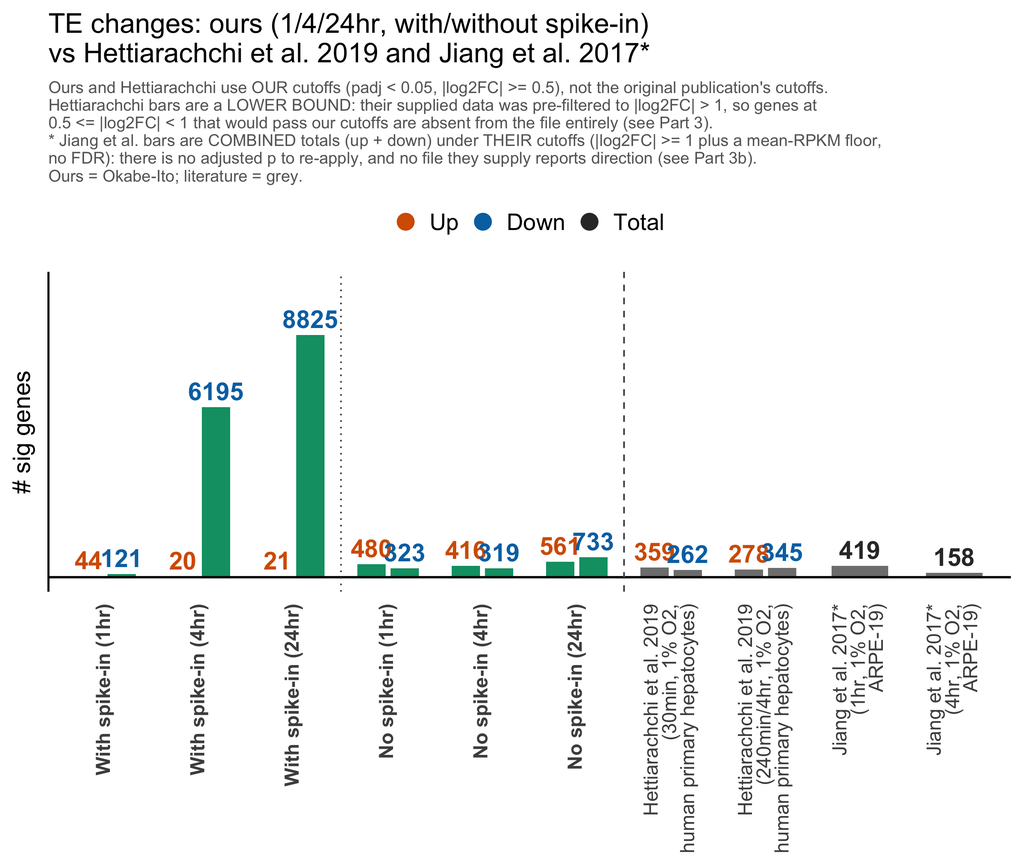

```r
library(ggtext)

y_pad <- 0.20 * max(te_vs_hetti$n)
dodge <- position_dodge(width = 0.7)

p_te_vs_hetti <- ggplot(te_vs_hetti, aes(x = source, y = n, fill = source, group = Direction)) +
  geom_col(position = dodge, width = 0.6) +
  geom_text(aes(label = n, color = Direction), position = dodge,
            vjust = -0.4, size = 8, fontface = "bold", key_glyph = "point") +
  geom_hline(yintercept = 0, linewidth = 1) +
  geom_vline(xintercept = n_with_spike + 0.5, linetype = "dotted", linewidth = 0.7, color = "grey30") +
  geom_vline(xintercept = n_ours + 0.5, linetype = "dashed", linewidth = 0.7, color = "grey30") +
  scale_fill_manual(values = source_colors, guide = "none") +
  scale_color_manual(values = c(Up = up_dark, Down = down_dark, Total = total_grey), name = NULL) +
  scale_y_continuous(limits = c(0, max(te_vs_hetti$n) + y_pad)) +
  scale_x_discrete(limits = source_levels) +
  guides(color = guide_legend(override.aes = list(size = 7))) +
  labs(title = "TE changes: ours (1/4/24hr, with/without spike-in)\nvs Hettiarachchi et al. 2019 and Jiang et al. 2017*",
       subtitle = paste0(
         "Ours and Hettiarachchi use OUR cutoffs (padj < 0.05, |log2FC| >= 0.5), not the original publication's cutoffs.\n",
         "Hettiarachchi bars are a LOWER BOUND: their supplied data was pre-filtered to |log2FC| > 1, so genes at\n",
         "0.5 <= |log2FC| < 1 that would pass our cutoffs are absent from the file entirely (see Part 3).\n",
         "* Jiang et al. bars are COMBINED totals (up + down) under THEIR cutoffs (|log2FC| >= 1 plus a mean-RPKM floor,\n",
         "no FDR): there is no adjusted p to re-apply, and no file they supply reports direction (see Part 3b).\n",
         "Ours = Okabe-Ito; literature = grey."
       ),
       x = NULL, y = "# sig genes") +
  theme_classic(base_size = 24) +
  theme(legend.position = "top",
        legend.text = element_text(size = 21),
        plot.title = element_text(size = 25),
        plot.subtitle = element_text(color = "grey40", size = 15),
        axis.line.y = element_line(linewidth = 0.9),
        axis.ticks.y = element_blank(),
        axis.text.y = element_blank(),
        axis.title.y = element_text(size = 22),
        axis.line.x = element_blank(),
        axis.ticks.x = element_blank(),
        axis.text.x = element_markdown(size = 18, angle = 90, hjust = 1, vjust = 0.5))

p_te_vs_hetti
```

```r
ggsave(here("plots/02_bar_te_all_timepoints_spike_vs_nospike_vs_hettiarachchi_and_jiang.pdf"),
       plot = p_te_vs_hetti, width = 13, height = 11)
```

# Part 5: RNA & Ribo comparison vs Shen et al. 2020 (hypoxic rat cardiomyocytes)

Shen JJ, et al. “Translatome and Transcriptome Profiling of Hypoxic-Induced Rat Cardiomyocytes.” *Molecular Therapy Nucleic Acids* 2020. DOI: 10.1016/j.omtn.2020.09.010 (PMC7689039).

Unlike Part 4 (TE), this comparison uses **RNA and Ribo separately** (ours, 4hr only — the closest of our timepoints to Shen et al.’s 8h — with and without spike-in) against Shen et al.’s **RNA-seq (transcriptome)** and **polyribo-seq (translatome)** DEG counts — matching metric to metric instead of comparing TE to a non-TE metric. Only the **8h vs normoxia** comparison is used for both RNA-seq and Ribo-seq (a true hypoxia-vs-normoxia comparison, like ours); the paper’s 24h-vs-8h comparisons (severe vs. mild hypoxia, NOT vs. normoxia — see prior discussion) are excluded from this plot entirely, for both modalities, since that isn’t the comparison type this plot is built around.

- **Cell type:** rat cardiac myoblast **H9C2** cell line (in vitro; the paper’s in vivo rat left-ventricle arm is not used here).
- **O2%:** 1% O2 (94% N2, 5% CO2) vs standard culture normoxia.
- **Timepoint:** 8h hypoxia. Not an exact match to our 4hr timepoint (longer).
- **No spike-in normalization used.** Confirmed directly: Shen et al. quantify with StringTie FPKM values and call differential expression with Ballgown — no ERCC or exogenous RNA spike-ins anywhere in their pipeline. So every Shen et al. bar in this plot is effectively a “no spike-in” condition, unlike our own bars (which show both).
- **Their cutoffs:** |log2FC| >= 1 and **raw p < 0.05** (Ballgown, not BH-adjusted padj) — looser statistical correction than ours (padj < 0.05).
- **No supplementary per-gene file used for a re-filter under our own cutoffs.** Ballgown’s output does not report an `lfcSE` column, so even with the raw supplementary tables (Table S3 = RNA-seq, Table S4 = polyribo-seq DEGs) there is no valid way to propagate error into a padj for a derived quantity — the counts below are the paper’s own reported totals, taken as-is, not recomputed under our thresholds.

```r
shen_groups <- tribble(
  ~source, ~Direction, ~n,
  "Shen et al. 2020<br>(H9C2, RNA-seq, 8hr, 1% O2, |log2FC| >= 1, p < 0.05)", "Up", 1527,
  "Shen et al. 2020<br>(H9C2, RNA-seq, 8hr, 1% O2, |log2FC| >= 1, p < 0.05)", "Down", 1398,
  "Shen et al. 2020<br>(H9C2, Ribo-seq, 8hr, 1% O2, |log2FC| >= 1, p < 0.05)", "Up", 536,
  "Shen et al. 2020<br>(H9C2, Ribo-seq, 8hr, 1% O2, |log2FC| >= 1, p < 0.05)", "Down", 429
)

our_rna_ribo <- sig_counts_long %>%
  filter(Mode %in% c("RNA", "Ribo"), Timepoint == "4hr") %>%
  transmute(
    modality = as.character(Mode),
    source = paste0("**", Mode, ": ", spike_status, " (", Timepoint, ")**"),
    Direction, n
  )

rna_source_levels <- c(
  "**RNA: With spike-in (4hr)**", "**RNA: No spike-in (4hr)**",
  "Shen et al. 2020<br>(H9C2, RNA-seq, 8hr, 1% O2, |log2FC| >= 1, p < 0.05)"
)
ribo_source_levels <- c(
  "**Ribo: With spike-in (4hr)**", "**Ribo: No spike-in (4hr)**",
  "Shen et al. 2020<br>(H9C2, Ribo-seq, 8hr, 1% O2, |log2FC| >= 1, p < 0.05)"
)

rna_vs_shen <- bind_rows(
  our_rna_ribo %>% filter(modality == "RNA") %>% dplyr::select(source, Direction, n),
  shen_groups %>% filter(grepl("RNA-seq", source))
) %>%
  mutate(Direction = factor(Direction, levels = c("Up", "Down")),
         source = factor(source, levels = rna_source_levels))

ribo_vs_shen <- bind_rows(
  our_rna_ribo %>% filter(modality == "Ribo") %>% dplyr::select(source, Direction, n),
  shen_groups %>% filter(grepl("Ribo-seq", source))
) %>%
  mutate(Direction = factor(Direction, levels = c("Up", "Down")),
         source = factor(source, levels = ribo_source_levels))

print(rna_vs_shen)
```

```
## # A tibble: 6 × 3
##   source                                                         Direction     n
##   <fct>                                                          <fct>     <dbl>
## 1 **RNA: With spike-in (4hr)**                                   Up           70
## 2 **RNA: With spike-in (4hr)**                                   Down       2809
## 3 **RNA: No spike-in (4hr)**                                     Up          511
## 4 **RNA: No spike-in (4hr)**                                     Down        454
## 5 Shen et al. 2020<br>(H9C2, RNA-seq, 8hr, 1% O2, |log2FC| >= 1… Up         1527
## 6 Shen et al. 2020<br>(H9C2, RNA-seq, 8hr, 1% O2, |log2FC| >= 1… Down       1398
```

```r
print(ribo_vs_shen)
```

```
## # A tibble: 6 × 3
##   source                                                         Direction     n
##   <fct>                                                          <fct>     <dbl>
## 1 **Ribo: With spike-in (4hr)**                                  Up           15
## 2 **Ribo: With spike-in (4hr)**                                  Down       8445
## 3 **Ribo: No spike-in (4hr)**                                    Up          413
## 4 **Ribo: No spike-in (4hr)**                                    Down        421
## 5 Shen et al. 2020<br>(H9C2, Ribo-seq, 8hr, 1% O2, |log2FC| >= … Up          536
## 6 Shen et al. 2020<br>(H9C2, Ribo-seq, 8hr, 1% O2, |log2FC| >= … Down        429
```

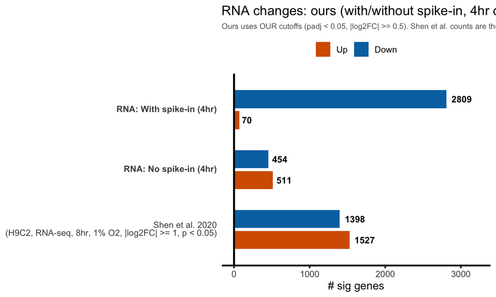

```r
make_rna_ribo_bar <- function(df, source_levels_local, modality_label) {
  x_pad_local <- 0.15 * max(df$n)
  ggplot(df, aes(y = source, x = n, fill = Direction)) +
    geom_col(position = dodge, width = 0.6) +
    geom_text(aes(label = n), position = dodge, hjust = -0.25, size = 3.5, fontface = "bold") +
    geom_vline(xintercept = 0, linewidth = 1) +
    scale_fill_manual(values = c(Up = up_dark, Down = down_dark)) +
    scale_x_continuous(limits = c(0, max(df$n) + x_pad_local)) +
    scale_y_discrete(limits = rev(source_levels_local)) +
    labs(title = paste0(modality_label, " changes: ours (with/without spike-in, 4hr only) vs Shen et al. 2020"),
         subtitle = "Ours uses OUR cutoffs (padj < 0.05, |log2FC| >= 0.5). Shen et al. counts are their own reported 8hr-vs-normoxia totals (|log2FC| >= 1, raw p < 0.05, not BH-adjusted), not recomputed under our cutoffs.",
         x = "# sig genes", y = NULL, fill = NULL) +
    theme_classic(base_size = 12) +
    theme(legend.position = "top",
          plot.subtitle = element_text(color = "grey40", size = 8.5),
          axis.line.x = element_line(linewidth = 0.9),
          axis.ticks.x = element_line(linewidth = 0.9),
          axis.line.y = element_blank(),
          axis.ticks.y = element_blank(),
          axis.text.y = element_markdown(size = 9.5))
}

p_rna_vs_shen <- make_rna_ribo_bar(rna_vs_shen, rna_source_levels, "RNA")
p_rna_vs_shen
```

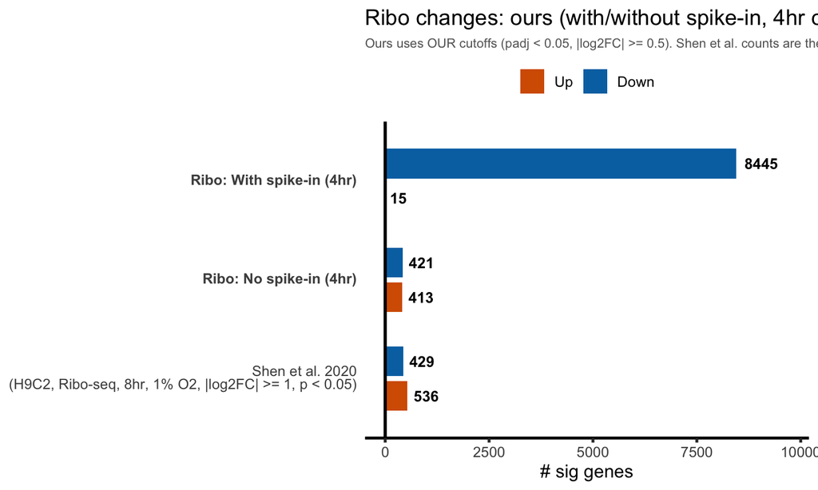

```r
ggsave(here("plots/02_bar_rna_vs_shen.pdf"), plot = p_rna_vs_shen, width = 7.5, height = 4.5)

p_ribo_vs_shen <- make_rna_ribo_bar(ribo_vs_shen, ribo_source_levels, "Ribo")
p_ribo_vs_shen
```

```r
ggsave(here("plots/02_bar_ribo_vs_shen.pdf"), plot = p_ribo_vs_shen, width = 7.5, height = 4.5)
```

# Part 6: RNA & Ribo versions of the Part 4 (TE) plot, one modality per plot

Same 04-style layout as Part 4’s TE-vs-Hettiarachchi plot (source labels on the x-axis, bars up, dotted line splitting with-spike/no-spike “ours” blocks, dashed line before literature, ours = Okabe-Ito, literature = grey) — but for RNA and Ribo instead of TE, each as its own plot rather than one combined chart, since Shen et al. 2020’s RNA-seq and Ribo-seq numbers are different modalities and don’t belong on the same “# sig genes” axis as each other (or as our TE bars). Each plot pairs our own RNA (or Ribo) with/without spike-in counts at all three timepoints (1/4/24hr) against Shen et al. 2020’s matching modality (their only reported hypoxia-vs-normoxia timepoint, 8h) — see Part 5 above for full sourcing/caveats on the Shen et al. numbers reused here.

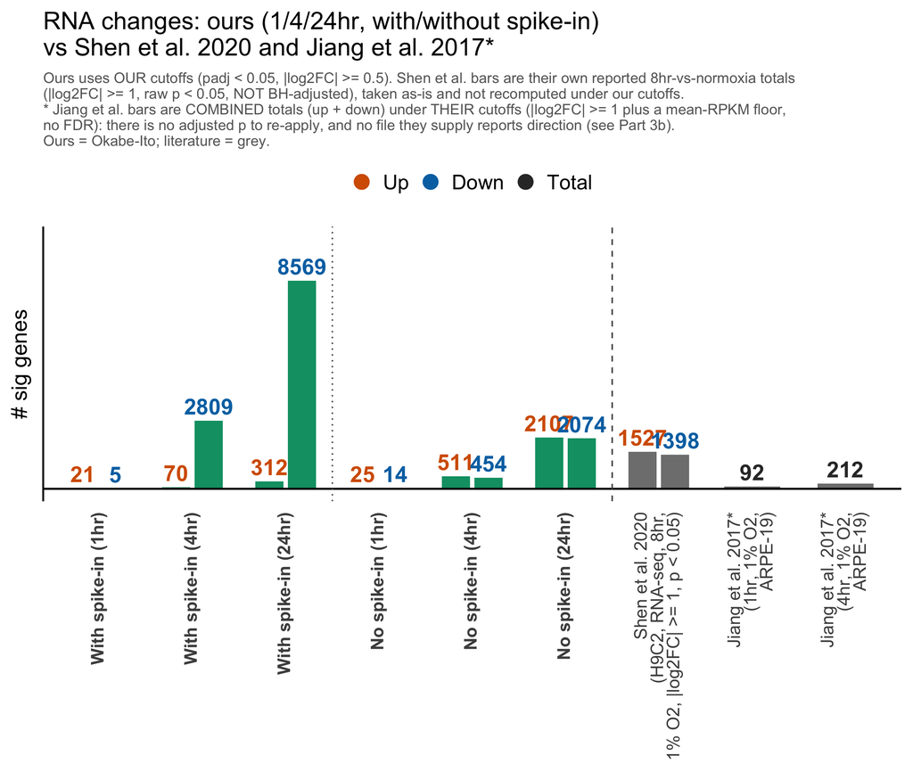

```r
make_ours_vs_lit_plot <- function(mode, literature_df, literature_levels, mode_label,
                                  lit_label_short, subtitle_text) {
  ours_levels <- c(
    paste0("**With spike-in (", levels(sig_counts_long$Timepoint), ")**"),
    paste0("**No spike-in (", levels(sig_counts_long$Timepoint), ")**")
  )
  n_ours <- length(ours_levels)
  n_with_spike <- length(levels(sig_counts_long$Timepoint))

  our_data <- sig_counts_long %>%
    filter(Mode == mode) %>%
    mutate(spike_status = factor(spike_status, levels = c("With spike-in", "No spike-in"))) %>%
    transmute(source = paste0("**", spike_status, " (", Timepoint, ")**"), Direction, n)

  source_levels_local <- c(ours_levels, literature_levels)

  plot_df <- bind_rows(our_data, literature_df) %>%
    mutate(Direction = factor(Direction, levels = c("Up", "Down", "Total")),
           source = factor(source, levels = source_levels_local))

  stopifnot("literature bars lost when joining onto our counts" =
    all(literature_levels %in% as.character(plot_df$source)))

  source_colors_local <- setNames(
    c(rep(ours_color, n_ours), rep(literature_color, length(literature_levels))),
    source_levels_local
  )

  y_pad_local <- 0.20 * max(plot_df$n)
  dodge_local <- position_dodge(width = 0.7)

  ggplot(plot_df, aes(x = source, y = n, fill = source, group = Direction)) +
    geom_col(position = dodge_local, width = 0.6) +
    geom_text(aes(label = n, color = Direction), position = dodge_local,
              vjust = -0.4, size = 8, fontface = "bold", key_glyph = "point") +
    geom_hline(yintercept = 0, linewidth = 1) +
    geom_vline(xintercept = n_with_spike + 0.5, linetype = "dotted", linewidth = 0.7, color = "grey30") +
    geom_vline(xintercept = n_ours + 0.5, linetype = "dashed", linewidth = 0.7, color = "grey30") +
    scale_fill_manual(values = source_colors_local, guide = "none") +
    scale_color_manual(values = c(Up = up_dark, Down = down_dark, Total = total_grey), name = NULL) +
    scale_y_continuous(limits = c(0, max(plot_df$n) + y_pad_local)) +
    scale_x_discrete(limits = source_levels_local) +
    guides(color = guide_legend(override.aes = list(size = 7))) +
    labs(title = paste0(mode_label, " changes: ours (1/4/24hr, with/without spike-in)\nvs ", lit_label_short),
         subtitle = subtitle_text,
         x = NULL, y = "# sig genes") +
    theme_classic(base_size = 24) +
    theme(legend.position = "top",
          legend.text = element_text(size = 21),
          plot.title = element_text(size = 25),
          plot.subtitle = element_text(color = "grey40", size = 15),
          axis.line.y = element_line(linewidth = 0.9),
          axis.ticks.y = element_blank(),
          axis.text.y = element_blank(),
          axis.title.y = element_text(size = 22),
          axis.line.x = element_blank(),
          axis.ticks.x = element_blank(),
          axis.text.x = element_markdown(size = 18, angle = 90, hjust = 1, vjust = 0.5))
}

shen_rna_literature <- tribble(
  ~source, ~Direction, ~n,
  "Shen et al. 2020<br>(H9C2, RNA-seq, 8hr,<br>1% O2, |log2FC| >= 1, p < 0.05)", "Up", 1527,
  "Shen et al. 2020<br>(H9C2, RNA-seq, 8hr,<br>1% O2, |log2FC| >= 1, p < 0.05)", "Down", 1398
)
jiang_rna_literature <- jiang_plot_counts %>%
  filter(Modality == "RNA") %>%
  dplyr::select(source, Direction, n)

shen_rna_literature <- bind_rows(shen_rna_literature, jiang_rna_literature)
shen_rna_levels <- unique(shen_rna_literature$source)

# Shen et al.'s bars are their OWN reported totals under their OWN cutoffs, not
# re-filtered under ours (Ballgown reports no lfcSE, so no padj can be derived
# for a re-count) - see Part 5. Their threshold is stricter on LFC (>= 1 vs our
# >= 0.5) but looser on multiple testing (raw p vs our BH padj), so the net
# direction of the bias is not knowable; say so rather than implying a
# common-cutoff comparison.
shen_subtitle <- paste0(
  "Ours uses OUR cutoffs (padj < 0.05, |log2FC| >= 0.5). Shen et al. bars are their own reported 8hr-vs-normoxia totals\n",
  "(|log2FC| >= 1, raw p < 0.05, NOT BH-adjusted), taken as-is and not recomputed under our cutoffs.\n",
  "* Jiang et al. bars are COMBINED totals (up + down) under THEIR cutoffs (|log2FC| >= 1 plus a mean-RPKM floor,\n",
  "no FDR): there is no adjusted p to re-apply, and no file they supply reports direction (see Part 3b).\n",
  "Ours = Okabe-Ito; literature = grey."
)

shen_ribo_literature <- tribble(
  ~source, ~Direction, ~n,
  "Shen et al. 2020<br>(H9C2, Ribo-seq, 8hr,<br>1% O2, |log2FC| >= 1, p < 0.05)", "Up", 536,
  "Shen et al. 2020<br>(H9C2, Ribo-seq, 8hr,<br>1% O2, |log2FC| >= 1, p < 0.05)", "Down", 429
)
jiang_ribo_literature <- jiang_plot_counts %>%
  filter(Modality == "Ribo") %>%
  dplyr::select(source, Direction, n)

shen_ribo_literature <- bind_rows(shen_ribo_literature, jiang_ribo_literature)
shen_ribo_levels <- unique(shen_ribo_literature$source)

p_rna_04style <- make_ours_vs_lit_plot(
  mode = "RNA", literature_df = shen_rna_literature, literature_levels = shen_rna_levels,
  mode_label = "RNA", lit_label_short = "Shen et al. 2020 and Jiang et al. 2017*",
  subtitle_text = shen_subtitle
)
p_rna_04style
```

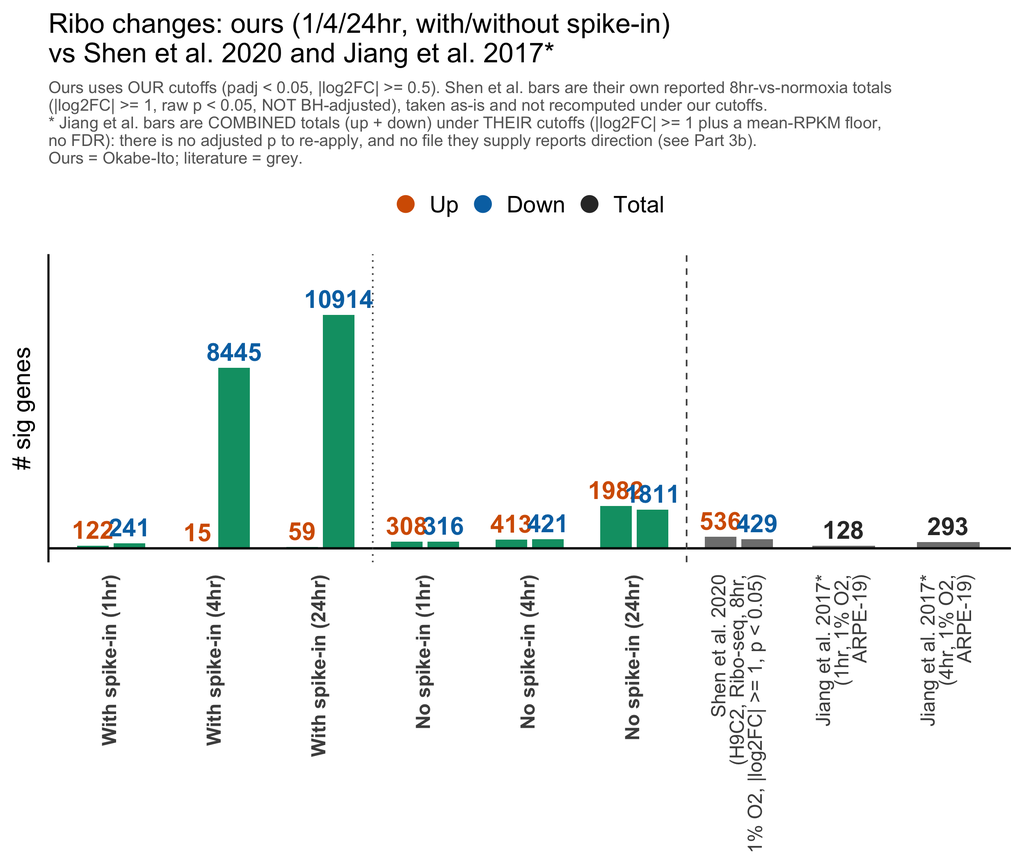

```r
ggsave(here("plots/02_bar_rna_all_timepoints_spike_vs_nospike_vs_shen_and_jiang.pdf"),
       plot = p_rna_04style, width = 13, height = 11)

p_ribo_04style <- make_ours_vs_lit_plot(
  mode = "Ribo", literature_df = shen_ribo_literature, literature_levels = shen_ribo_levels,
  mode_label = "Ribo", lit_label_short = "Shen et al. 2020 and Jiang et al. 2017*",
  subtitle_text = shen_subtitle
)
p_ribo_04style
```

```r
ggsave(here("plots/02_bar_ribo_all_timepoints_spike_vs_nospike_vs_shen_and_jiang.pdf"),
       plot = p_ribo_04style, width = 13, height = 11)
```